# Peer-graded Assignment: Prediction Assignment Writeup

Francesco Mancino

31 de enero de 2019

## Final project for the Practical Machine Learning Course.

The goal of your project is to predict the manner in which they did the exercise. This is the “classe” variable in the training set. You may use any of the other variables to predict with. You should create a report describing how you built your model, how you used cross validation, what you think the expected out of sample error is, and why you made the choices you did. You will also use your prediction model to predict 20 different test cases.

## First steps

Once uploaded the training and testing datasets, an exploratory analysis was made to determind: Types of variables, structure of the variables (factor, numeric, integer etc), any anomalies in the variables.

```r
training<-read.csv("C:/Users/fmancino/Desktop/R/Practical Machine Learning Course/pml-training.csv",
                   na.strings = c(" #DIV/0!","#DIV/0!"))

testing<-read.csv("C:/Users/fmancino/Desktop/R/Practical Machine Learning Course/pml-testing.csv")

sum(!complete.cases(training)) ##no complete cases in the training dataset
```

```
## [1] 19622
```

```r
sum(!complete.cases(testing)) ##no complete cases in the testing dataset
```

```
## [1] 20
```

```r
summary(training)
```

```
##        X            user_name    raw_timestamp_part_1 raw_timestamp_part_2
##  Min.   :    1   adelmo  :3892   Min.   :1.322e+09    Min.   :   294
##  1st Qu.: 4906   carlitos:3112   1st Qu.:1.323e+09    1st Qu.:252912
##  Median : 9812   charles :3536   Median :1.323e+09    Median :496380
##  Mean   : 9812   eurico  :3070   Mean   :1.323e+09    Mean   :500656
##  3rd Qu.:14717   jeremy  :3402   3rd Qu.:1.323e+09    3rd Qu.:751891
##  Max.   :19622   pedro   :2610   Max.   :1.323e+09    Max.   :998801
##
##           cvtd_timestamp  new_window    num_window      roll_belt
##  28/11/2011 14:14: 1498   no :19216   Min.   :  1.0   Min.   :-28.90
##  05/12/2011 11:24: 1497   yes:  406   1st Qu.:222.0   1st Qu.:  1.10
##  30/11/2011 17:11: 1440               Median :424.0   Median :113.00
##  05/12/2011 11:25: 1425               Mean   :430.6   Mean   : 64.41
##  02/12/2011 14:57: 1380               3rd Qu.:644.0   3rd Qu.:123.00
##  02/12/2011 13:34: 1375               Max.   :864.0   Max.   :162.00
##  (Other)         :11007
##    pitch_belt          yaw_belt       total_accel_belt kurtosis_roll_belt
##  Min.   :-55.8000   Min.   :-180.00   Min.   : 0.00    Min.   :-2.121
##  1st Qu.:  1.7600   1st Qu.: -88.30   1st Qu.: 3.00    1st Qu.:-1.329
##  Median :  5.2800   Median : -13.00   Median :17.00    Median :-0.899
##  Mean   :  0.3053   Mean   : -11.21   Mean   :11.31    Mean   :-0.220
##  3rd Qu.: 14.9000   3rd Qu.:  12.90   3rd Qu.:18.00    3rd Qu.:-0.219
##  Max.   : 60.3000   Max.   : 179.00   Max.   :29.00    Max.   :33.000
##                                                        NA's   :19226
##  kurtosis_picth_belt kurtosis_yaw_belt skewness_roll_belt
##  Min.   :-2.190      Mode:logical      Min.   :-5.745
##  1st Qu.:-1.107      NA's:19622        1st Qu.:-0.444
##  Median :-0.151                        Median : 0.000
##  Mean   : 4.334                        Mean   :-0.026
##  3rd Qu.: 3.178                        3rd Qu.: 0.417
##  Max.   :58.000                        Max.   : 3.595
##  NA's   :19248                         NA's   :19225
##  skewness_roll_belt.1 skewness_yaw_belt max_roll_belt   max_picth_belt
##  Min.   :-7.616       Mode:logical      NA     :19216   NA     :19216
##  1st Qu.:-1.114       NA's:19622        -87.9  :   11   18     :  100
##  Median :-0.068                         166    :   11   5      :   65
##  Mean   :-0.296                         -87.6  :   10   3      :   50
##  3rd Qu.: 0.661                         -87.7  :   10   4      :   40
##  Max.   : 7.348                         -88.2  :   10   20     :   36
##  NA's   :19248                          (Other):  354   (Other):  115
```

[output cut: 297 more lines]

```
##  Min.   : -8.0900   Min.   :-498.00   Min.   :-632.0   Min.   :-446.00
##  1st Qu.: -0.1800   1st Qu.:-178.00   1st Qu.:  57.0   1st Qu.:-182.00
##  Median :  0.0800   Median : -57.00   Median : 201.0   Median : -39.00
##  Mean   :  0.1512   Mean   : -61.65   Mean   : 163.7   Mean   : -55.29
##  3rd Qu.:  0.4900   3rd Qu.:  76.00   3rd Qu.: 312.0   3rd Qu.:  26.00
##  Max.   :231.0000   Max.   : 477.00   Max.   : 923.0   Max.   : 291.00
##
##  magnet_forearm_x  magnet_forearm_y magnet_forearm_z classe
##  Min.   :-1280.0   Min.   :-896.0   Min.   :-973.0   A:5580
##  1st Qu.: -616.0   1st Qu.:   2.0   1st Qu.: 191.0   B:3797
##  Median : -378.0   Median : 591.0   Median : 511.0   C:3422
##  Mean   : -312.6   Mean   : 380.1   Mean   : 393.6   D:3216
##  3rd Qu.:  -73.0   3rd Qu.: 737.0   3rd Qu.: 653.0   E:3607
##  Max.   :  672.0   Max.   :1480.0   Max.   :1090.0
##
```

From the summary of variables it was possible to determind that many variables had more than 80% of missing values. The neccesary step was to delete these variables from the dataset and consider only variabels with no missing values.

```r
myvars<-names(training) %in% c("X", "raw_timestamp_part_1", "raw_timestamp_part_2",
"kurtosis_yaw_belt", "skewness_yaw_belt", "max_roll_belt", "max_picth_belt",
"min_roll_belt",  "min_pitch_belt", "amplitude_roll_belt", "amplitude_pitch_belt",
"amplitude_yaw_belt", "var_total_accel_belt", "avg_roll_belt", "stddev_roll_belt",
"var_roll_belt", "avg_pitch_belt", "stddev_pitch_belt", "var_pitch_belt", "avg_yaw_belt",
"stddev_yaw_belt",  "var_yaw_belt", "var_accel_arm", "avg_roll_arm", "stddev_roll_arm",
"var_roll_arm", "avg_pitch_arm", "stddev_pitch_arm", "var_pitch_arm", "avg_yaw_arm", "stddev_yaw_arm",
"var_yaw_arm", "max_roll_arm", "max_picth_arm",  "max_yaw_arm", "min_roll_arm", "min_pitch_arm",
"min_yaw_arm", "amplitude_roll_arm", "amplitude_pitch_arm", "amplitude_yaw_arm", "kurtosis_yaw_dumbbell",
"skewness_yaw_dumbbell", "max_roll_dumbbell","max_picth_dumbbell",  "min_roll_dumbbell", "min_pitch_forearm",
"amplitude_roll_forearm", "amplitude_pitch_forearm", "amplitude_yaw_forearm", "var_accel_forearm",
"avg_roll_forearm",  "stddev_roll_forearm", "var_roll_forearm", "avg_pitch_forearm", "stddev_pitch_forearm",
"var_pitch_forearm", "avg_yaw_forearm", "stddev_yaw_forearm", "var_yaw_forearm",
"kurtosis_yaw_forearm","skewness_yaw_forearm", "min_pitch_dumbbell", "min_yaw_dumbbell", "amplitude_roll_dumbbell",
"amplitude_yaw_forearm", "amplitude_pitch_dumbbell", "amplitude_yaw_dumbbell", "total_accel_dumbbell", "var_accel_dumbbell",
"avg_roll_dumbbell", "stddev_roll_dumbbell", "var_roll_dumbbell", "avg_pitch_dumbbell", "stddev_pitch_dumbbell",
"var_pitch_dumbbell", "avg_yaw_dumbbell", "stddev_yaw_dumbbell", "var_yaw_dumbbell", "kurtosis_roll_belt",
"kurtosis_picth_belt", "skewness_roll_belt", "skewness_roll_belt.1", "max_yaw_belt", "min_yaw_belt",
"kurtosis_roll_arm", "kurtosis_picth_arm", "kurtosis_yaw_arm", "skewness_roll_arm",
"skewness_pitch_arm", "skewness_yaw_arm", "kurtosis_roll_dumbbell",
"kurtosis_picth_dumbbell", "skewness_roll_dumbbell", "skewness_pitch_dumbbell", "max_yaw_dumbbell",
"kurtosis_roll_forearm","kurtosis_picth_forearm", "skewness_roll_forearm", "skewness_pitch_forearm", "max_roll_forearm",
"max_picth_forearm","max_yaw_forearm", "min_yaw_forearm", "min_roll_forearm", "cvtd_timestamp", "new_window", "num_window")

df<-training[!myvars]
```

The remaining variabels where then changed to numeric format, except for user name and classe.

```r
df$total_accel_belt<-as.numeric(df$total_accel_belt)
cols = c(8:14, 17:18, 21:27, 33:38, 42:43, 46:50)
df[,cols]= apply(df[,cols], 2, function(x) as.numeric(as.character(x)))
```

## Descriptive Statistics

Some descriptive statistics were made on selected variables to explore the behaviour of the variables and their relationships.

Tables

```r
table(df$user_name, df$classe)
```

```
##
##               A    B    C    D    E
##   adelmo   1165  776  750  515  686
##   carlitos  834  690  493  486  609
##   charles   899  745  539  642  711
##   eurico    865  592  489  582  542
##   jeremy   1177  489  652  522  562
##   pedro     640  505  499  469  497
```

```r
a1<-aggregate(df$roll_belt, by=list(df$user_name, df$classe), FUN= mean)
a2<-aggregate(df$pitch_belt, by=list(df$user_name, df$classe), FUN= mean)
a3<-aggregate(df$yaw_belt, by=list(df$user_name, df$classe), FUN= mean)
a4<-aggregate(df$roll_arm, by=list(df$user_name, df$classe), FUN= mean)
a5<-aggregate(df$pitch_arm, by=list(df$user_name, df$classe), FUN= mean)
a6<-aggregate(df$yaw_arm, by=list(df$user_name, df$classe), FUN= mean)

a1
```

```
##     Group.1 Group.2            x
## 1    adelmo       A 123.64120172
## 2  carlitos       A   1.29449640
## 3   charles       A 116.09121246
## 4    eurico       A   1.33820809
## 5    jeremy       A   0.67561597
## 6     pedro       A 124.58125000
## 7    adelmo       B 125.41108247
## 8  carlitos       B   1.31904348
## 9   charles       B 116.05503356
## 10   eurico       B   1.23037162
## 11   jeremy       B   0.70525562
## 12    pedro       B 122.10099010
## 13   adelmo       C 126.31333333
## 14 carlitos       C   1.31533469
```

[output cut: 16 more lines]

```r
a2
```

```
##     Group.1 Group.2           x
## 1    adelmo       A -42.7110730
## 2  carlitos       A   7.4583813
## 3   charles       A  21.2685206
## 4    eurico       A   4.2556069
## 5    jeremy       A   4.8886916
## 6     pedro       A  26.5128125
## 7    adelmo       B -44.0202320
## 8  carlitos       B   6.2749275
## 9   charles       B  16.8626846
## 10   eurico       B   2.8938345
## 11   jeremy       B   4.3217791
## 12    pedro       B  26.4714851
## 13   adelmo       C -41.6286667
## 14 carlitos       C   6.3560243
```

[output cut: 16 more lines]

```r
a3
```

```
##     Group.1 Group.2           x
## 1    adelmo       A 169.4557940
## 2  carlitos       A -93.6937650
## 3   charles       A  -5.9699110
## 4    eurico       A -87.9203468
## 5    jeremy       A -88.1470688
## 6     pedro       A  -1.9608281
## 7    adelmo       B 148.4317010
## 8  carlitos       B -92.5481159
## 9   charles       B  -5.3727383
## 10   eurico       B -88.6471284
## 11   jeremy       B -87.9022495
## 12    pedro       B  -4.6036634
## 13   adelmo       C 163.0920000
## 14 carlitos       C -92.7294118
```

[output cut: 16 more lines]

```r
a4
```

```
##     Group.1 Group.2          x
## 1    adelmo       A  -9.038352
## 2  carlitos       A -52.781942
## 3   charles       A -33.331813
## 4    eurico       A  78.843121
## 5    jeremy       A   0.000000
## 6     pedro       A  20.558187
## 7    adelmo       B  -2.217822
## 8  carlitos       B  92.243913
## 9   charles       B -49.188993
## 10   eurico       B 100.885135
## 11   jeremy       B   0.000000
## 12    pedro       B  72.340851
## 13   adelmo       C  -9.645773
## 14 carlitos       C  84.331846
```

[output cut: 16 more lines]

```r
a5
```

```
##     Group.1 Group.2           x
## 1    adelmo       A  30.5220000
## 2  carlitos       A   5.9267266
## 3   charles       A -31.0520578
## 4    eurico       A   7.6247399
## 5    jeremy       A   0.0000000
## 6     pedro       A  -0.4697344
## 7    adelmo       B   0.3565206
## 8  carlitos       B -18.1776087
## 9   charles       B  -4.4358792
## 10   eurico       B  -7.7447297
## 11   jeremy       B   0.0000000
## 12    pedro       B  -9.4130891
## 13   adelmo       C   7.1799067
## 14 carlitos       C  -6.9498174
```

[output cut: 16 more lines]

Grapghs

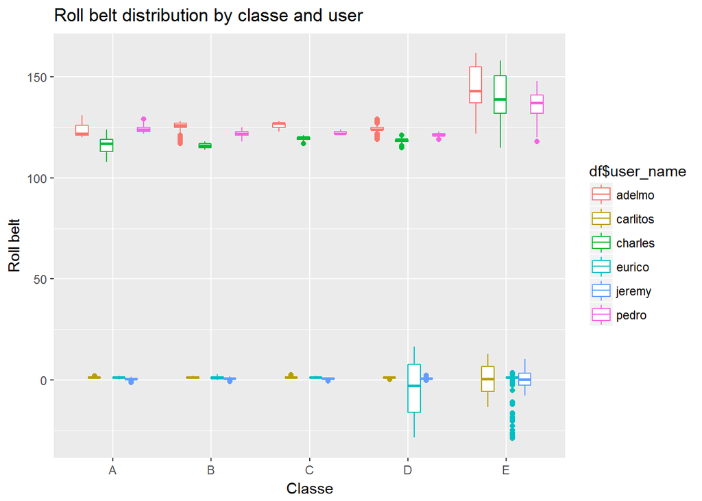

```r
library(ggplot2)
g1<-ggplot(data=df, aes(x=df$classe, y=df$roll_belt, colour= df$user_name))+ geom_boxplot() +
  labs(title="Roll belt distribution by classe and user", x="Classe", y="Roll belt")

g2<-ggplot(data=df, aes(x=df$classe, y=df$pitch_belt, colour= df$user_name))+ geom_boxplot() +
  labs(title="Pitch belt distribution by classe and user", x="Classe", y="Roll belt")

g3<-ggplot(data=df, aes(x=df$classe, y=df$yaw_belt, colour= df$user_name))+ geom_boxplot() +
  labs(title="Yaw belt distribution by classe and user", x="Classe", y="Roll belt")

g4<-ggplot(data=df, aes(x=df$classe, y=df$roll_arm, colour= df$user_name))+ geom_boxplot() +
  labs(title="Roll arm distribution by classe and user", x="Classe", y="Roll belt")

g5<-ggplot(data=df, aes(x=df$classe, y=df$pitch_arm, colour= df$user_name))+ geom_boxplot() +
 labs(title="Pitch arm distribution by classe and user", x="Classe", y="Roll belt")

g5<-ggplot(data=df, aes(x=df$classe, y=df$total_accel_belt, colour= df$user_name))+ geom_boxplot() +
  labs(title="Total acceletarion belt distribution by classe and user", x="Classe", y="Roll belt")

library(caret)
p1<-featurePlot(x=df[,c("roll_belt","pitch_belt","yaw_belt",
                         "total_accel_belt")],
                y=df$classe, plot="pairs")

g1
```

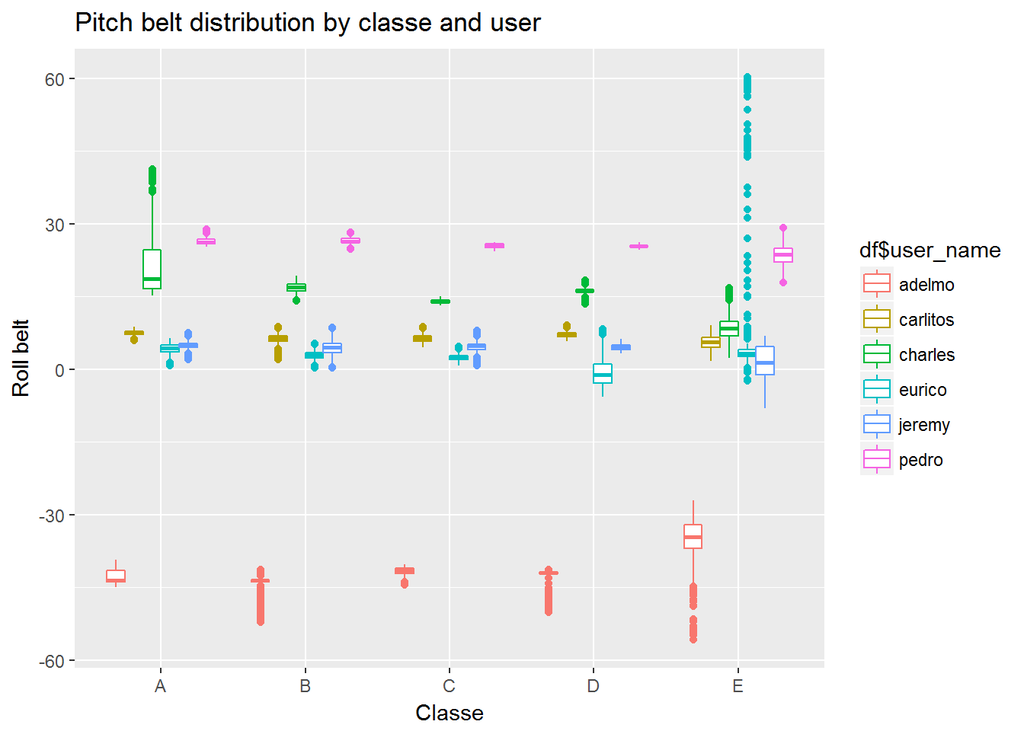

```r
g2
```

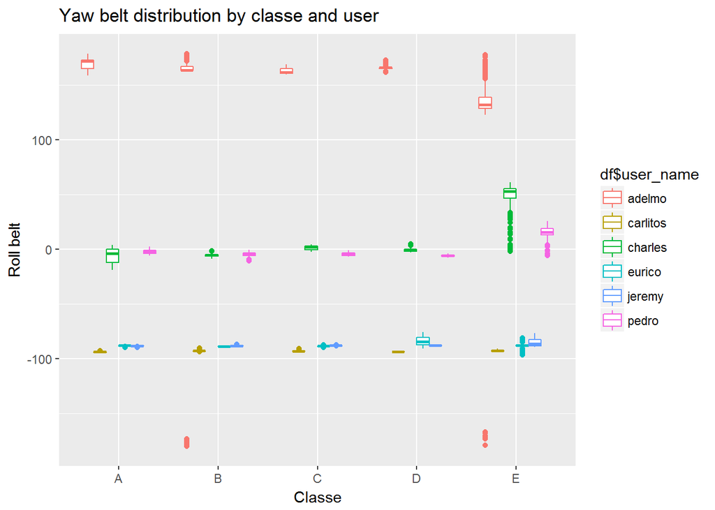

```r
g3
```

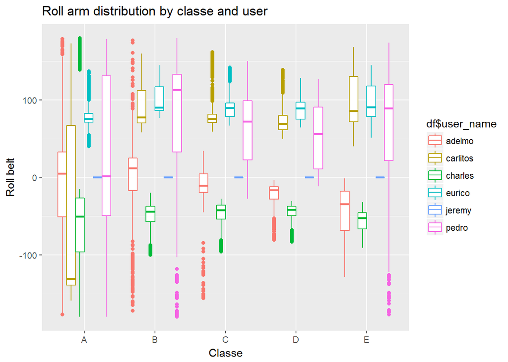

```r
g4
```

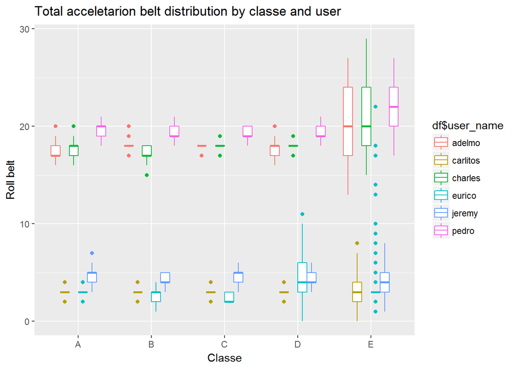

```r
g5
```

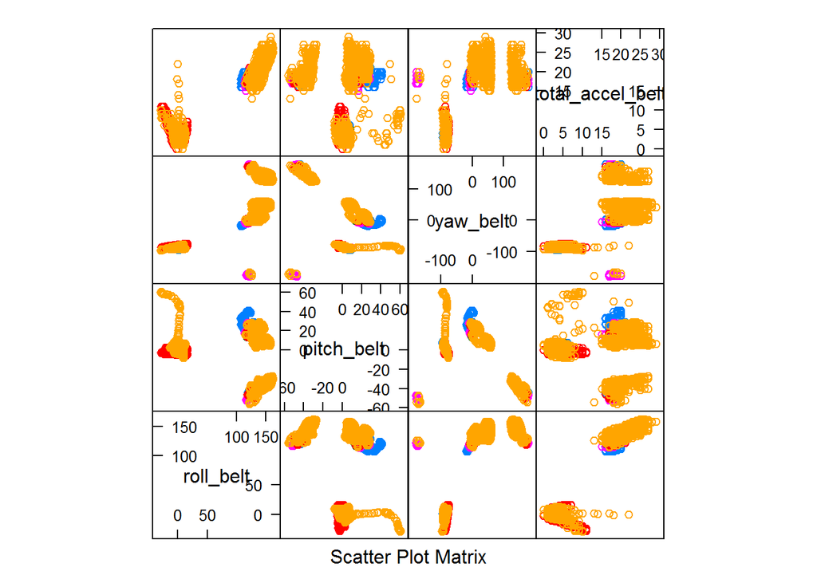

```r
p1
```

We can tell from total accelaration belt and the roll belt distribution grapghs that there are two very marked groups. One group has higher measures (mean of aporx 120) and groups with lower values (mean near 0). I can tell that Adelmo, Charles and Pedro belong in the high activity group while Carlitos, Eurico and Jeremy belong in the lower activity group. All users perform the 5 types of activities.

## Calssification model: Random Forest

```r
library(randomForest)
set.seed(1234)
fit.forest <- randomForest(classe~., data=df,
                             na.action=na.roughfix,
                             importance=TRUE)

importance(fit.forest, type=2)
```

```
##                     MeanDecreaseGini
## user_name                  174.42353
## roll_belt                 1292.11204
## pitch_belt                 700.17935
## yaw_belt                   926.29822
## total_accel_belt           223.80801
## gyros_belt_x                93.03843
## gyros_belt_y               110.03242
## gyros_belt_z               296.84712
## accel_belt_x               115.97789
## accel_belt_y               121.76829
## accel_belt_z               402.19951
## magnet_belt_x              249.14771
## magnet_belt_y              366.04828
## magnet_belt_z              397.34194
## roll_arm                   309.36038
## pitch_arm                  179.89197
## yaw_arm                    251.86357
## total_accel_arm            101.87085
## gyros_arm_x                129.65054
## gyros_arm_y                138.41819
## gyros_arm_z                 54.56511
## accel_arm_x                233.97136
## accel_arm_y                145.79015
## accel_arm_z                125.07440
## magnet_arm_x               251.15496
## magnet_arm_y               229.04632
## magnet_arm_z               185.50554
## roll_dumbbell              414.16891
## pitch_dumbbell             174.51091
## yaw_dumbbell               262.51338
## gyros_dumbbell_x           125.87733
## gyros_dumbbell_y           249.32202
## gyros_dumbbell_z            80.99602
## accel_dumbbell_x           259.39902
## accel_dumbbell_y           432.23666
## accel_dumbbell_z           358.78224
## magnet_dumbbell_x          503.85838
## magnet_dumbbell_y          677.02166
## magnet_dumbbell_z          738.19923
## roll_forearm               633.09820
## pitch_forearm              784.15988
## yaw_forearm                182.13917
## total_accel_forearm        112.98251
## gyros_forearm_x             73.73435
## gyros_forearm_y            125.06851
## gyros_forearm_z             81.64168
## accel_forearm_x            318.28109
## accel_forearm_y            145.79450
## accel_forearm_z            233.33623
## magnet_forearm_x           227.16119
## magnet_forearm_y           223.02566
## magnet_forearm_z           289.69613
```

```r
fit.forest
```

```
##
## Call:
##  randomForest(formula = classe ~ ., data = df, importance = TRUE,      na.action = na.roughfix)
##                Type of random forest: classification
##                      Number of trees: 500
## No. of variables tried at each split: 7
##
##         OOB estimate of  error rate: 0.28%
## Confusion matrix:
##      A    B    C    D    E  class.error
## A 5578    2    0    0    0 0.0003584229
## B   10 3783    4    0    0 0.0036871214
## C    0   11 3411    0    0 0.0032144944
## D    0    0   20 3194    2 0.0068407960
## E    0    0    2    4 3601 0.0016634322
```

```r
forest.pred <- predict(fit.forest, testing)
forest.pred
```

```
##  1  2  3  4  5  6  7  8  9 10 11 12 13 14 15 16 17 18 19 20
##  B  A  B  A  A  E  D  B  A  A  B  C  B  A  E  E  A  B  B  B
## Levels: A B C D E
```

There were 500 trees grown by sampling 19622 observations with replacement. The out of bag estimate error rate was of 0.28%, this is the error rate obtained by classifying the cases that aren´t selected when building a tree.